# Working with Sample Data

```r
library(dplyr)
library(qSIP2)
packageVersion("qSIP2")
```

```
#> [1] '0.10.1'
```

# Sample Metadata

In `qSIP2`, “sample data” refers to any metadata associated with the individual fractions or their sequencing data. This is the second level of metadata - more granular than “source data”, but at a higher-level than the “feature data”.

## What is a sample?

The word **sample** typically refers to the biological or environmental entity the DNA was isolated (aka the **source material**). In qSIP, however, because there are multiple sequencing runs per **source**, the term **sample** has historically been reserved for sequencing of each fraction. In practice, this means you will have many **samples** for each single **source**. To keep with the proposed MISIP[^1] standards, the source material is coded with the `source_mat_id`, and each sequencing run/fraction is coded with the `sample_id`.

# Sample Metadata

The sample data has the most requirements to pass validation of the three qSIP input types. To standardize these requirements the column names should adhere as closely to MISIP standards where possible. Absolute requirements are slightly different than the official MISIP standards, and for the `qSIP2` package would be the `source_mat_id`, `sample_id`, `gradient_position`, `gradient_pos_density` and `gradient_pos_rel_amt` fields.

## `source_mat_id` and `sample_id` columns

One column of the metadata should contain a unique `sample_id` that is associated with a `source_mat_id`. The format of the `sample_id` doesn’t matter, as long as it is unique. A popular choice might be the `source_mat_id` appended with the gradient position.

Sample `source_mat_id` and `sample_id` pairs

| source_mat_id | sample_id |
| --- | --- |
| A | A_1 |
| A | A_2 |
| A | A_3 |
| B | B_1 |
| B | B_2 |
| B | B_3 |

Each `source_mat_id` should match to one row on the `qsip_source_data` dataframe. And although the `sample_id` should be unique for each row, it is expected that the `source_mat_id` will be duplicated.

## `gradient_position` and `gradient_pos_density` columns

These are columns conforming to the MISIP standards to describe the position and density values for each `sample_id`. Although only `gradient_position` is required for MISIP, they are both required for qSIP.

`gradient_position` is typically numbered by decreasing density, so the heaviest will be `1`, second heaviest will be `2`, etc. To pass `qSIP2` validation the `gradient_position` must be a positive integer, but `-1` will also be accepted to designate a “bulk” sample (although these are not used in `qSIP2`). `gradient_position` is not used directly in `qSIP2` calculations but can be useful for quality control (see below).

`gradient_pos_density` is reported as g/ml with as much decimal place precision as your method allows.

## `gradient_pos_amt` and `gradient_pos_rel_amt` columns

A requirement for qSIP is the `gradient_pos_rel_amt` field, which gives the percent amount that a fraction has of the whole. The preferred method is given in qPCR copy numbers, but DNA concentrations can be used as well.

The `gradient_pos_rel_amt` column is required for MISIP standards, but for `qSIP2` we also require an additional `gradient_pos_amt` column with the “raw” abundance values for each sample. This requirement is because typically a qSIP workflow will produce the `gradient_pos_amt` values, and the `gradient_pos_rel_amt` can be derived from it using the `add_gradient_pos_rel_amt()` function. This function simply totals up the `gradient_pos_amt` for each sample in a source, and then divides by the total. This math is the same whether using qPCR amplicon copies or total DNA isolated.

For example, if there are 100,000 total 16S copies in a source as determined by qPCR, and 15,000 copies in fraction 7, then the `gradient_pos_rel_amt` value for fraction 7 would be 0.15 (15,000 / 100,000). Similarly, if you had 25ng total DNA used for density separation, and fraction 7 had 3.75 ng DNA recovered, then `gradient_pos_rel_amt` would also be 0.15 (3.75 / 25).

Ideally, all of the `gradient_pos_rel_amt` for a given `source_mat_id` should add up to 1[^2], but there are situations where it might be less than 1. For example, if you removed some fractions because they didn’t sequence well or there was some other reason to remove a fraction. If you have 16S or DNA concentrations for these removed samples they would be subtracted from the total. So, for our example above, if fraction 7 needed to be removed, then the total for all fractions of that `source_mat_id` would only be 0.85. Another situation would be that although you added 25ng to a centrifugation, you only recovered 20ng and the rest was lost[^3]. The total fractions within a `source_mat_id` within should never be greater than 1.

### `add_gradient_pos_rel_amt()` function

You can use a total abundance (qPCR or DNA concentrations) to calculate the `gradient_pos_rel_amt` column.

```r
sample_df <- add_gradient_pos_rel_amt(example_sample_df,
  source_mat_id = "source",
  amt = "avg_16S_g_soil"
)
```

sample data with `gradient_pos_rel_amt` added

| sample | source | Fraction | density_g_ml | dna_conc | avg_16S_g_soil | gradient_pos_rel_amt |
| --- | --- | --- | --- | --- | --- | --- |
| 149_F1 | S149 | 1 | 1.778855 | 0.000000000 | 4473.7081 | 1.284122e-04 |
| 149_F2 | S149 | 2 | 1.773391 | 0.000000000 | 986.6581 | 2.832078e-05 |
| 149_F3 | S149 | 3 | 1.765742 | 0.000000000 | 4002.7026 | 1.148925e-04 |
| 149_F4 | S149 | 4 | 1.759185 | 0.000000000 | 3959.7283 | 1.136590e-04 |
| 149_F5 | S149 | 5 | 1.752629 | 0.001241303 | 5725.7319 | 1.643499e-04 |
| 149_F6 | S149 | 6 | 1.746072 | 0.012815610 | 7566.2722 | 2.171803e-04 |

Trying to run this function on a dataframe with an existing `gradient_pos_rel_amt` will give an error, but it can be overridden with the `overwrite = T` flag.

```r
sample_df |>
  add_gradient_pos_rel_amt(
    source_mat_id = "source",
    amt = "avg_16S_g_soil"
  )
```

```
#> Error: gradient_pos_rel_amt already exists! Set overwrite = TRUE if you want to overwrite
```

```r
sample_df |>
  add_gradient_pos_rel_amt(
    source_mat_id = "source",
    amt = "avg_16S_g_soil",
    overwrite = T
  )
```

# Making a `qsip_sample_data` object

The `qsip_sample_data` constructor builds a sample data object from the dataframe. We can use the `sample_df` we built above (with the relative amounts) to build the qsip object. We can take another look at it to make sure we have the column names we will need.

First few rows of formatted sample data

| sample | source | Fraction | density_g_ml | avg_16S_g_soil | gradient_pos_rel_amt |
| --- | --- | --- | --- | --- | --- |
| 149_F1 | S149 | 1 | 1.778855 | 4473.7081 | 1.284122e-04 |
| 149_F2 | S149 | 2 | 1.773391 | 986.6581 | 2.832078e-05 |
| 149_F3 | S149 | 3 | 1.765742 | 4002.7026 | 1.148925e-04 |
| 149_F4 | S149 | 4 | 1.759185 | 3959.7283 | 1.136590e-04 |
| 149_F5 | S149 | 5 | 1.752629 | 5725.7319 | 1.643499e-04 |
| 149_F6 | S149 | 6 | 1.746072 | 7566.2722 | 2.171803e-04 |

```r
sample_object <- qsip_sample_data(sample_df,
  sample_id = "sample",
  source_mat_id = "source",
  gradient_position = "Fraction",
  gradient_pos_density = "density_g_ml",
  gradient_pos_amt = "avg_16S_g_soil",
  gradient_pos_rel_amt = "gradient_pos_rel_amt"
)
```

```
#> Error: some gradient_position values are non-numeric
```

Here is an example of the `qSIP2` validation error telling us we have characters in the `gradient_position` field. A simple `mutate()` call to convert to integers will fix the problem, giving a valid `qsip_sample_data` object.

```r
sample_object <- sample_df |>
  mutate(Fraction = as.integer(Fraction)) |>
  qsip_sample_data(
    sample_id = "sample",
    source_mat_id = "source",
    gradient_position = "Fraction",
    gradient_pos_density = "density_g_ml",
    gradient_pos_amt = "avg_16S_g_soil",
    gradient_pos_rel_amt = "gradient_pos_rel_amt"
  )
```

# Working with a `qsip_sample_data` object

The `sample_object` created above is ready for the next step in the main workflow, but we can also use it for some intermediate analysis and QC.

## Look for density outliers

Sometimes there might be errors in the density values in a spreadsheet, particularly if they are entered by hand. The `plot_density_outliers()` can help identify these outliers using Cook’s distance and a specified `sensitivity` value. The lower the `sensitivity` parameter, the more sensitive the algorithm is to calling a point an outlier.

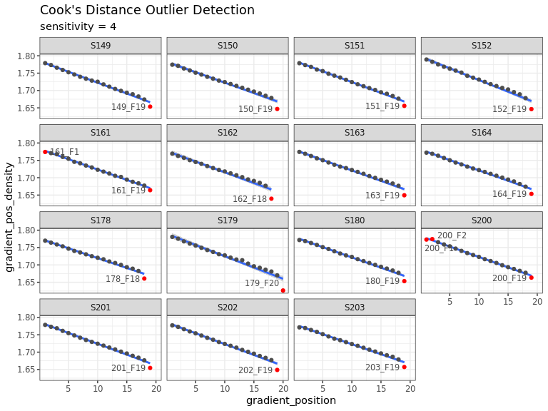

```r
plot_density_outliers(sample_object)
```

Here we see some values at the ends of the density ranges are slightly lower than their gradient position would suggest, and are therefore considered possible outliers and colored red. The ends of the density ranges, however, are expected to fall off of the main line, and so these results are not too concerning here.

## Plotting density data

There are two functions to visualize the density values in the sample data, but they also require a `qsip_source_data` object. The `qSIP2` package includes an example version called `example_source_object`.

The first is to plot the sample curves according to their gradient density and tube relative abundance. The vertical dotted lines are the average weighted density (WAD) for that source.

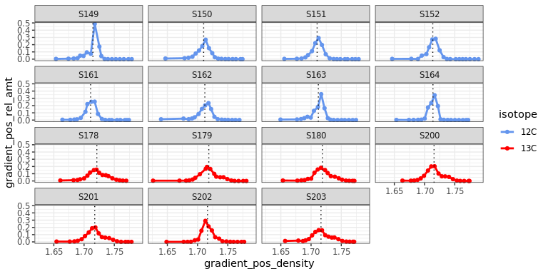

```r
plot_sample_curves(
  sample_data = sample_object,
  source_data = example_source_object,
  colors = c("12C" = "cornflowerblue", "13C" = "red")
)
```

The WAD values can be pulled out for each source and plotted together, for better comparison.

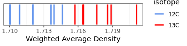

```r
plot_source_wads(
  sample_data = sample_object,
  source_data = example_source_object,
  colors = c("12C" = "cornflowerblue", "13C" = "red")
)
```

These can be further grouped according to other columns in the `source_data`.

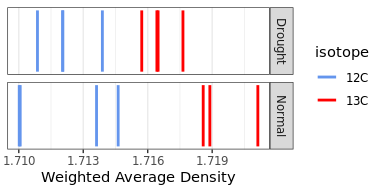

```r
plot_source_wads(
  sample_data = sample_object,
  source_data = example_source_object,
  group = "Moisture",
  colors = c("12C" = "cornflowerblue", "13C" = "red")
)
```

[^1]: https://www.biorxiv.org/content/10.1101/2023.07.13.548835v1
[^2]: The `add_gradient_pos_rel_amt()` function will always give totals equal to 1.
[^3]: [The angel’s share and devil’s cut](https://www.visitlex.com/guides/post/common-geeky-bourbon-terms-explained/#:~:text=Angel's%20Share)